# Targeting Carbon-Intensive Growth: A Data-Driven Recommendation for Australia’s Indo-Pacific Clean Energy Partnerships

Author

Henry Ou

# Client Bio

Source: DCCEEW official website [1] [2]

Australian Government Client

Client: DCCEEW, the Australian Government department responsible for climate change, energy, environment and water policy. Its climate and international action remit makes it a relevant client for prioritising Indo-Pacific clean-energy partnerships.[3] [4]

# Recommendation

DCCEEW should prioritise Vietnam and Indonesia for partnership support, use India as a supporting coal-dependence case, and treat Australia, Japan and South Korea as benchmarks.

1. **Primary:** Vietnam and Indonesia.
2. **Supporting:** India.
3. **Benchmarks:** Australia, Japan and South Korea.

# Key Insights

Trajectory Signal 0

Vietnam’s carbon intensity is higher than in 2012, making it the clearest case of stalled decoupling in the focus group.

Rule-Based Screen 0economies

Only 7 economies in 2022 have a coal share between 40% and 60% combined with positive 10-year CO2 growth; Vietnam and Indonesia are two of them.

Global Hypothesis Test 0

A 10-point rise in coal share is associated with roughly 12.2% higher carbon intensity in the full 2022 cross-country sample.

The evidence chain is strongest when the figures are read together rather than separately: Figure 1 identifies the priority zone, Figure 2 tests whether high intensity is persistent, and Figure 3 explains which partnership lever matters once a country is prioritised.

# Evidence

Total emissions alone are not enough: China, the United States and India are the largest 2022 emitters, but prioritisation is about transition leverage, not scale. Figure 1 maps carbon intensity, 10-year CO2 growth, total CO2 and coal share. Vietnam combines 357 t CO2 per million 2011 PPP$ with +106.3% CO2 growth; Indonesia combines +42.9% growth with a 54.9% coal share; all three benchmarks record negative CO2 growth.

**Code — evidence setup for the main figures**

```r
# Focus economies and benchmark labels used across Figures 1-3
focus_target    <- c("Indonesia", "Vietnam", "India")
focus_benchmark <- c("Australia", "Japan", "South Korea")
focus_all       <- c(focus_target, focus_benchmark)

# Country-level OWID rows only; OWID aggregate regions are excluded
co2_countries <- co2_raw |>
  filter(!is.na(iso_code), !str_starts(iso_code, "OWID")) |>
  mutate(
    carbon_intensity = co2 / gdp * 1e12,
    coal_share = coal_co2 / co2,
    oil_share = oil_co2 / co2,
    gas_share = gas_co2 / co2,
    cement_share = cement_co2 / co2
  )

# Ten-year growth and intensity-change summaries used in Figure 1 and the table
growth_10yr <- co2_countries |>
  filter(year %in% c(2012, 2022)) |>
  select(country, iso_code, year, co2) |>
  pivot_wider(names_from = year, values_from = co2, names_prefix = "co2_") |>
  mutate(co2_growth_10yr_pct = (co2_2022 - co2_2012) / co2_2012 * 100) |>
  select(country, iso_code, co2_growth_10yr_pct)

intensity_change <- co2_countries |>
  filter(year %in% c(2012, 2022)) |>
  select(country, year, carbon_intensity) |>
  pivot_wider(names_from = year, values_from = carbon_intensity,
              names_prefix = "intensity_") |>
  mutate(intensity_change_pct =
           (intensity_2022 - intensity_2012) / intensity_2012 * 100) |>
  select(country, intensity_change_pct)

# Latest complete-year panel for the report's decision map
latest_panel_all <- co2_countries |>
  filter(year == 2022, co2 > 0, gdp > 0) |>
  select(country, co2, gdp, carbon_intensity,
         coal_share, oil_share, gas_share, cement_share) |>
  left_join(growth_10yr |> select(country, co2_growth_10yr_pct), by = "country") |>
  left_join(intensity_change, by = "country")

latest_panel_focus <- latest_panel_all |>
  filter(country %in% focus_all) |>
  mutate(
    priority_level = case_when(
      country %in% c("Indonesia", "Vietnam") ~ "Primary target",
      country == "India" ~ "Supporting case",
      TRUE ~ "Benchmark"
    )
  )

# These objects feed the three interactive SVG figures in the Evidence section
priority_widget_data <- latest_panel_all |> filter(!is.na(carbon_intensity), !is.na(coal_share))
trend_widget_data    <- trend_data      |> filter(country %in% focus_all)
fuel_widget_data     <- fuel_long       |> filter(country %in% focus_all)
```

**Code — Figure 1 priority map**

```r
priority_widget_data <- latest_panel_all |>
  mutate(
    role = case_when(
      country %in% c("Vietnam", "Indonesia") ~ "target",
      country %in% c("Australia", "Japan", "South Korea") ~ "benchmark",
      TRUE ~ "other"
    ),
    coal_category = case_when(
      coal_share >= 0.60 ~ "High coal share",
      coal_share >= 0.30 ~ "Moderate coal share",
      TRUE ~ "Lower coal share"
    )
  )

# The document emits this object as JSON and a small JavaScript/SVG layer draws:
# x = carbon_intensity, y = 10-year CO2 growth, size = total CO2,
# fill = coal category, and buttons = all / priority / benchmark focus.
emit_json("priority-data", list(points = priority_widget_data))
```

Figure 1

Total emissions do not tell DCCEEW where partnership leverage is greatest

Figure 2 adds trajectory. Since 2012, Vietnam’s carbon intensity has risen by +14.4%, Indonesia’s has fallen by only 5.7%, and India still records 270 t CO2 per million 2011 PPP$. Australia, Japan and South Korea each decline by about a quarter, indicating much stronger decoupling.

**Code — Figure 2 carbon-intensity trajectories**

```r
trend_widget_data <- co2_countries |>
  filter(country %in% focus_all, year >= 1990, year <= 2022) |>
  select(country, year, carbon_intensity) |>
  filter(!is.na(carbon_intensity)) |>
  mutate(role = case_when(
    country %in% c("Vietnam", "Indonesia", "India") ~ "target",
    TRUE ~ "benchmark"
  ))

trend_endpoint_data <- trend_widget_data |>
  group_by(country) |>
  filter(year == max(year)) |>
  ungroup()

# JavaScript reads `trend-data` and draws one line per economy, with buttons
# that dim non-priority or non-benchmark series without changing the data.
emit_json("trend-data", list(series = trend_widget_data,
                             endpoints = trend_endpoint_data))
```

Figure 2

Carbon intensity matters most when it is read as a trajectory

Figure 3 identifies the relevant partnership lever. Coal still supplies 65.6% of India’s CO2, 54.9% of Indonesia’s and 52.8% of Vietnam’s, so the recommendation points toward clean-power finance, grid flexibility and coal displacement rather than generic climate diplomacy. This reading is consistent with IEA (2024a), IEA (2024b), IPCC (2022) and World Bank (2023).

**Code — Figure 3 CO2 composition by source**

```r
fuel_long <- latest_panel_focus |>
  transmute(
    country,
    Coal   = coal_share,
    Oil    = oil_share,
    Gas    = gas_share,
    Cement = cement_share
  ) |>
  pivot_longer(-country, names_to = "source", values_to = "share") |>
  filter(!is.na(share))

fuel_order <- fuel_long |>
  filter(source == "Coal") |>
  arrange(desc(share)) |>
  pull(country)

# JavaScript reads `fuel-data` and draws a sorted stacked bar chart.
# The "Coal focus" button desaturates oil/gas/cement to foreground coal.
emit_json("fuel-data", list(segments = fuel_long, order = fuel_order))
```

Figure 3

Coal dependence turns a general climate issue into a specific partnership target

Coal Oil Gas Cement

The hypothesis test extends the sample to every country with complete 2022 data. A log-linear regression finds a positive association between coal share and carbon intensity (beta = 1.15, p < 0.001, n = 129), so the visual pattern is not just a six-country artifact. Coal share is used here as a prioritisation signal, not as sole causal proof.

Taken together, the evidence directly supports the recommendation: Vietnam and Indonesia combine the clearest priority-zone position, weaker decoupling and coal-heavy transition levers; India remains a supporting case because its coal dependence is high but its intensity trajectory is less stalled. This is a prioritisation guide, not project selection; feasibility, cost and local grid constraints still require due diligence.

```r
priority_table_display |>
  kable(
    format = "html",
    escape = FALSE,
    table.attr = "class='summary-table'"
  )
```

Table 1: Curated evidence for the six focus economies.

| Country | Carbon intensity (t / M 2011 PPP$) | Recent trend | Coal share | Priority level |
| --- | --- | --- | --- | --- |
| Indonesia | 211 | Only slight decoupling | 54.9% | Primary target |
| Vietnam | 357 | Intensity rising again | 52.8% | Primary target |
| India | 270 | Partial decoupling | 65.6% | Supporting case |
| Australia | 286 | Strong decoupling | 38.0% | Benchmark |
| Japan | 216 | Strong decoupling | 40.4% | Benchmark |
| South Korea | 282 | Strong decoupling | 44.5% | Benchmark |

# Statistical Support

## Hypothesis Test

To test whether coal-heavy systems are systematically more emissions-intensive, a 2022 cross-country log-linear regression models **log carbon intensity** on **coal share**. The estimated slope is **1.15** (SE **0.21**), with **t = 5.41**, **p < 0.001**, and **R-squared = 0.19** across **129 countries**.

The sample is widened from the six focus economies to every country with complete 2022 data, so the slope reflects a cross-country structural pattern rather than a six-point line.

**Code — fit log-linear model on the 2022 cross-section**

```r
# Widen to every country with complete intensity + coal share in 2022
reg_data <- latest_panel_all |>
  filter(!is.na(carbon_intensity), carbon_intensity > 0,
         !is.na(coal_share), coal_share >= 0, coal_share <= 1)

fit       <- lm(log(carbon_intensity) ~ coal_share, data = reg_data)
fit_tidy  <- broom::tidy(fit)      # coefficients, SE, t, p
fit_glance <- broom::glance(fit)   # R^2, F, df, n

# Headline slope on coal share + effect of a 10-point coal rise
beta1      <- fit_tidy |> filter(term == "coal_share") |> pull(estimate)
assoc_10pp <- (exp(beta1 * 0.10) - 1) * 100   # % change in intensity
```

Slope oncoal share 1.15

Intensity effectof a 10-point coal rise 12.2%

ModelR-squared 0.19

The result supports the report’s main argument: **coal dependence is strongly associated with higher carbon intensity across countries**. The model R² of 0.19 indicates that coal share alone explains roughly a fifth of the cross-country variation in log carbon intensity — consistent with using coal share as a screening signal rather than as a deterministic cause. This is not causal proof, but it reinforces the practical reading of the visuals: coal-heavy economies are more likely to benefit from targeted clean-energy transition support. Full HATPC detail is provided in the Appendix.

## Transition Gap

The headline slope on coal share is statistically significant — but for DCCEEW the more useful question is **how much that slope means in tonnes of CO2 per million 2011 PPP$**. The multivariate model in the Robustness Checks subsection lets us translate it into a decision-relevant counterfactual: *if a focus economy’s coal share matched the three-benchmark average (41%, the 2022 mean of Australia, Japan and South Korea), holding its own GDP per capita fixed, what would the model predict for its carbon intensity?*

**Code — transition-gap chart data**

```r
ctr_plot <- transition_widget_data |>
  mutate(
    country = factor(country, levels = rev(country)),
    label_x = pmin(pred_bench, pred_current) - 6
  )

transition_x_range <- range(c(ctr_plot$pred_current, ctr_plot$pred_bench))
```

Model Translation

### Coal-share alignment produces double-digit modelled gaps for the primary targets

Current Benchmark-share Gap

The model implies the largest single-variable intensity-reduction lever for **India** (**−25%**), consistent with India’s coal share being the highest in the focus group and therefore the furthest from the benchmark reference. **Indonesia** sits in the middle (**−15%**), and **Vietnam** at **−13%** — proportional to each country’s distance from the 41% benchmark coal share. The **benchmarks themselves** show ≈ 0% gaps because their 2022 coal shares are already at or near this reference value, which validates the construction of the metric: countries that already look like the benchmark have nothing to close. This does **not** automatically make India the first-order target, because the recommendation weighs a bundle of signals rather than the largest modelled coal-gap alone; Vietnam and Indonesia still combine weaker decoupling with a more focused Southeast Asian partnership setting. This priority framing also reflects DCCEEW’s existing Southeast-Asia partnership focus under the DFAT Southeast Asia Economic Strategy to 2040 ([4]), within which India enters as an indispensable South-Asian comparator rather than the primary deployment target.

Read the chart as a **directional indicator**, not a forecast. The gap is the model-implied effect of moving *only one input* — coal share — to a reference value, ceteris paribus. In reality, moving coal share also moves capital stock, employment, grid composition and policy; none of those second-order effects appear here. The chart answers a narrow question — *how much intensity reduction is encoded in coal-share targeting alone?* — and leaves feasibility, finance cost and political economy to the partnership-design stage.

What this adds to the recommendation: even on the most conservative reading (where the model captures only one structural channel), coal-share-led partnership support has a **double-digit** intensity-reduction signature for both primary targets. That justifies the priority call on *quantitative* terms, not just on level / trend / coal-share triangulation. In partnership-design terms, this means the same coal-share intervention is modelled to deliver a larger per-country intensity reduction in Vietnam and Indonesia than in already-decoupled economies — the structural argument for concentrating partnership effort where the structural lever is largest.

## Robustness Checks

The headline regression in the Hypothesis Test subsection uses one predictor on a 2022 cross-section. Three further models test whether the **coal-intensity signal** still appears under different lenses on the same OWID data. Each is a *robustness check*, not a causal proof: the report continues to read coal share as a **priority signal**, not a single decisive cause.

**Growth model**

Tests whether **10-year CO2 growth (2012–2022)** still tracks **2022 coal share** once **10-year GDP growth** is netted out — i.e. whether coal-heavy economies grow emissions faster *after* accounting for the fact that they may also grow GDP faster.

```r
growth_fit_tidy |>
  transmute(
    Term = case_when(
      term == "(Intercept)"           ~ "Intercept",
      term == "coal_share"            ~ "Coal share (2022)",
      term == "gdp_growth_10yr_pct"   ~ "GDP growth, 2012–2022 (%)",
      TRUE                            ~ term
    ),
    Estimate     = signif(estimate, 3),
    `Std. error` = signif(std.error, 3),
    `t-stat`     = signif(statistic, 3),
    `p-value`    = signif(p.value, 3),
    `CI 2.5%`    = signif(conf.low, 3),
    `CI 97.5%`   = signif(conf.high, 3)
  ) |>
  kable(format = "html", table.attr = "class='summary-table'")
```

Table 2: Growth model: CO2 growth (%, 2012–2022) regressed on 2022 coal share and GDP growth (%, 2012–2022).

| Term | Estimate | Std. error | t-stat | p-value | CI 2.5% | CI 97.5% |
| --- | --- | --- | --- | --- | --- | --- |
| Intercept | -22.60 | 9.22 | -2.450 | 0.0157 | -40.8 | -4.34 |
| Coal share (2022) | 17.80 | 23.30 | 0.764 | 0.4460 | -28.3 | 63.90 |
| GDP growth, 2012–2022 (%) | 1.28 | 0.19 | 6.720 | 0.0000 | 0.9 | 1.65 |

After controlling for GDP growth, the coal-share coefficient is **17.8** but **not statistically significant** (p = 0.446); the GDP-growth control is the dominant predictor (β = **1.28**, p < 0.001), with model R² = 0.27 on 129 countries. **The honest read: decade-on-decade CO2 growth is largely a GDP-growth story, not a pure coal-share story.** Coal share matters most for *how much CO2 each unit of GDP produces* (intensity, tested in the next two models) rather than for the absolute *rate of growth*. The Priority Map’s vertical axis should therefore be read as a development-trajectory signal, not as direct evidence that coal share drives growth.

**Intensity-change model**

Tests whether countries that **raised** coal share between 2012 and 2022 also saw their **carbon intensity rise** over the same window. Reading change-on-change instead of level-on-level partly differences out time-invariant country effects (geography, baseline industrial structure).

```r
change_fit_tidy |>
  transmute(
    Term = case_when(
      term == "(Intercept)"            ~ "Intercept",
      term == "coal_share_change_pp"   ~ "Δ coal share (pp, 2012–2022)",
      TRUE                             ~ term
    ),
    Estimate     = signif(estimate, 3),
    `Std. error` = signif(std.error, 3),
    `t-stat`     = signif(statistic, 3),
    `p-value`    = signif(p.value, 3),
    `CI 2.5%`    = signif(conf.low, 3),
    `CI 97.5%`   = signif(conf.high, 3)
  ) |>
  kable(format = "html", table.attr = "class='summary-table'")
```

Table 3: Intensity-change model: Δ carbon intensity (%, 2012–2022) regressed on Δ coal share (pp, 2012–2022).

| Term | Estimate | Std. error | t-stat | p-value | CI 2.5% | CI 97.5% |
| --- | --- | --- | --- | --- | --- | --- |
| Intercept | -6.04 | 2.840 | -2.13 | 0.0352 | -11.70 | -0.426 |
| Δ coal share (pp, 2012–2022) | 2.22 | 0.289 | 7.68 | 0.0000 | 1.64 | 2.790 |

A 1-percentage-point rise in coal share over the decade is associated with a **2.22%** change in carbon intensity (p < 0.001, R² = 0.32, n = 127). The effect is statistically strong and in the expected direction: countries that grew their coal share also saw intensity rise (or fall less). Because differences-on-differences partially absorb time-invariant country effects, this is the most robust of the three checks for the headline coal–intensity link. Still associational — strong directional evidence, not a causal coefficient.

**Multivariate intensity model**

Tests whether the **coal-share slope on log carbon intensity** survives once **log GDP per capita** is added as a control for development level. Many low-coal economies are also high-income service economies, so the headline univariate slope partly reflects this confound.

```r
intensity_fit_multivar_tidy |>
  transmute(
    Term = case_when(
      term == "(Intercept)"          ~ "Intercept",
      term == "coal_share"           ~ "Coal share (2022)",
      term == "log(gdp_per_capita)"  ~ "log GDP per capita (2022)",
      TRUE                           ~ term
    ),
    Estimate     = signif(estimate, 3),
    `Std. error` = signif(std.error, 3),
    `t-stat`     = signif(statistic, 3),
    `p-value`    = signif(p.value, 3),
    `CI 2.5%`    = signif(conf.low, 3),
    `CI 97.5%`   = signif(conf.high, 3)
  ) |>
  kable(format = "html", table.attr = "class='summary-table'")
```

Table 4: Multivariate intensity model: log(carbon intensity, 2022) regressed on coal share and log(GDP per capita, 2022).

| Term | Estimate | Std. error | t-stat | p-value | CI 2.5% | CI 97.5% |
| --- | --- | --- | --- | --- | --- | --- |
| Intercept | 4.6900 | 0.4100 | 11.400 | 0.00e+00 | 3.8800 | 5.50 |
| Coal share (2022) | 1.1600 | 0.2130 | 5.430 | 3.00e-07 | 0.7350 | 1.58 |
| log GDP per capita (2022) | 0.0363 | 0.0424 | 0.857 | 3.93e-01 | -0.0475 | 0.12 |

After adding log GDP per capita as a control, the coal-share slope is essentially unchanged: **1.16** versus the univariate **1.15**, still highly significant (p < 0.001, model R² = 0.19). The log GDP-per-capita coefficient is small (**0.04**) and **not statistically significant** (p = 0.393), suggesting that — within this linear specification — development level does not absorb additional variation in log carbon intensity once coal share is in the model. The coal signal therefore **survives the development control** rather than being explained away by the fact that wealthier economies happen to use less coal. This is the cleanest robustness result of the three: the headline coal–intensity association is not an artifact of conflating coal use with national income.

**What the three checks together support**

The three checks tell a consistent — but more nuanced — story than the headline regression alone. Coal share is **positively signed in all three specifications** and **statistically significant in two of three** (intensity-change and multivariate); it is **not significant** for decade-on-decade *growth* once GDP growth is controlled for. Read together:

- **Coal share is a robust signal for carbon intensity** (level and change). Its slope on log intensity barely moves when development level is added, and its decade-on-decade *change* tracks the change in intensity strongly.
- **Coal share is not, on its own, a robust signal for emissions growth**. Decade-on-decade growth is dominated by GDP growth itself, so the Priority Map’s growth axis should be read as a development-trajectory marker rather than as separate evidence of a coal effect.

Together the checks support reading coal share as a **priority indicator** for *what kind of partnership lever fits* (clean-power transition, grid flexibility), but they discipline the report against treating coal share as a one-cause explanation for emissions growth. The claims remain **associational** — robustness checks, not causal proof.

# Limitations

1. **OWID is mainly production-based.** The dataset measures territorial emissions, so it does not fully capture consumption-based responsibility or emissions embodied in trade. This matters when comparing developing production economies with higher-income consumption economies.[5] Conversely, this strengthens rather than weakens the case for partnership support: helping Vietnam and Indonesia decarbonise production also reduces the embodied carbon flowing into Australian and broader Indo-Pacific supply chains, an effect not visible in the territorial accounting used here.
2. **Country averages hide project detail.** National data cannot identify the provinces, sectors, grid constraints or financing windows where partnership support would land. The report prioritises *countries*, not specific investments.
3. **The statistical evidence is associational.** Coal share, carbon intensity and CO2 growth move together in useful ways, but the models do not prove that coal share alone *causes* higher intensity. Industrial structure, technology, regulation, energy prices and GDP growth also shape the results.
4. **Priority is not feasibility.** A high coal share signals both transition leverage and transition difficulty: embedded capital stock, employment exposure and grid design can make clean-energy support slower or more expensive. DCCEEW would still need country-level due diligence before designing projects.

# Statements

## Ethics Statement

This report follows the ISI shared value of professionalism and the ethical principle of pursuing objectivity by using public data, checking calculations against OWID, comparing countries on common indicators, and stating limits openly rather than implying causal certainty.

## AI usage statement

This report used ChatGPT-5 (OpenAI, https://openai.com/) to assist with feedback, drafting, wording refinement, data-pipeline review and HTML/CSS presentation.

AI was used only as an aid. All data processing, regression modelling, calculations and final interpretation were independently checked and decided by the author.

# Acknowledgements

- **Course support:** I sincerely thank the University of Sydney DATA1001 course team, including the Ed lessons, lecturers, tutors and teaching staff, for their guidance, project structure and statistical-reporting support, all of which shaped this work.
- **Dataset:** I thank *Our World in Data* for the public CO2 and Greenhouse Gas Emissions dataset (`owid-co2-data.csv`) and the open climate-data explanations that support transparent analysis: https://ourworldindata.org/co2-and-greenhouse-gas-emissions.
- **Report craft references:** I thank [Kaggle Code](https://www.kaggle.com/code) for public data-science report examples, [The Pudding](https://pudding.cool/) for visual-storytelling inspiration, and [The Data Journalism Handbook / DataJournalism.com](https://datajournalism.com/read/handbook/one) for helping me learn how data analysis can be shaped into a clearer story.
- **External evidence:** DCCEEW, DFAT, IEA, IPCC and World Bank sources listed below.
- **Software:** R, `tidyverse`, `readr`, `scales`, `broom`, `jsonlite`, and `knitr`.

# References

Department of Climate Change, Energy, the Environment and Water (DCCEEW). (2024). *About us*. Australian Government. https://www.dcceew.gov.au/about

Department of Climate Change, Energy, the Environment and Water (DCCEEW). (2023). *Who we are*. Australian Government. https://www.dcceew.gov.au/about/who-we-are

Department of Climate Change, Energy, the Environment and Water (DCCEEW). (2026). *International climate action*. Australian Government. https://www.dcceew.gov.au/climate-change/strategies/international-climate-change-commitments

Department of Foreign Affairs and Trade (DFAT). (2025). *Implementing Invested: Australia’s Southeast Asia Economic Strategy to 2040*. Australian Government. https://www.dfat.gov.au/countries-economies-and-regions/southeast-asia/invested-southeast-asia

DataJournalism.com. (n.d.). *The Data Journalism Handbook 1*. European Journalism Centre. https://datajournalism.com/read/handbook/one

Intergovernmental Panel on Climate Change (IPCC). (2022). *Climate Change 2022: Mitigation of Climate Change*. Cambridge University Press. https://www.ipcc.ch/report/ar6/wg3/

International Energy Agency (IEA). (2024a). *Southeast Asia Energy Outlook 2024*. IEA. https://www.iea.org/reports/southeast-asia-energy-outlook-2024

International Energy Agency (IEA). (2024b). *World Energy Investment 2024: Southeast Asia*. IEA. https://www.iea.org/reports/world-energy-investment-2024/southeast-asia

Kaggle. (n.d.). *Kaggle Code*. https://www.kaggle.com/code

Our World in Data. (2025). *CO2 and Greenhouse Gas Emissions*. https://ourworldindata.org/co2-and-greenhouse-gas-emissions

Peters, G. P., Minx, J. C., Weber, C. L., & Edenhofer, O. (2011). Growth in emission transfers via international trade from 1990 to 2008. *Proceedings of the National Academy of Sciences, 108*(21), 8903-8908. https://doi.org/10.1073/pnas.1006388108

The Pudding. (n.d.). *The Pudding*. https://pudding.cool/

World Bank. (2023). *Scaling Up to Phase Down*. World Bank. https://www.worldbank.org/en/topic/energy/publication/scaling-up-to-phase-down

# Appendix

Detailed diagnostics, full HATPC reporting and supplementary robustness visuals are collected here so the main report can stay reader-focused without losing analytical transparency.

## Appendix 1 — HATPC Process

Full Hypotheses / Assumptions / Test statistic / P-value / Conclusion (HATPC) detail for the log-linear regression used in the Hypothesis Test subsection.

**H**

**H — Hypotheses**

- **H0:** The slope on coal share is zero; coal dependence has no linear association with log carbon intensity.
- **H1:** The slope on coal share is not zero; coal dependence is associated with log carbon intensity.

**A**

**A — Assumptions**

- **Linearity:** The fitted log-linear form is appropriate as a first-order approximation for the cross-country relationship.
- **Normality:** Residuals are approximately normal after log transformation; Shapiro-Wilk **p = 0.179**.
- **Independence:** Each observation is a distinct country in the 2022 cross-section.
- **Scope:** The model is descriptive and cross-sectional, so it supports prioritisation rather than causal inference.

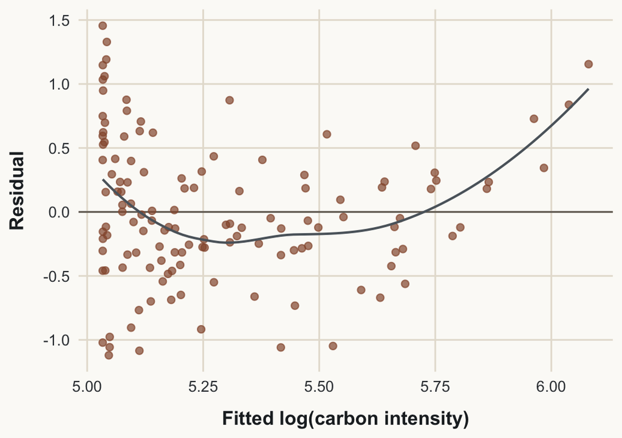

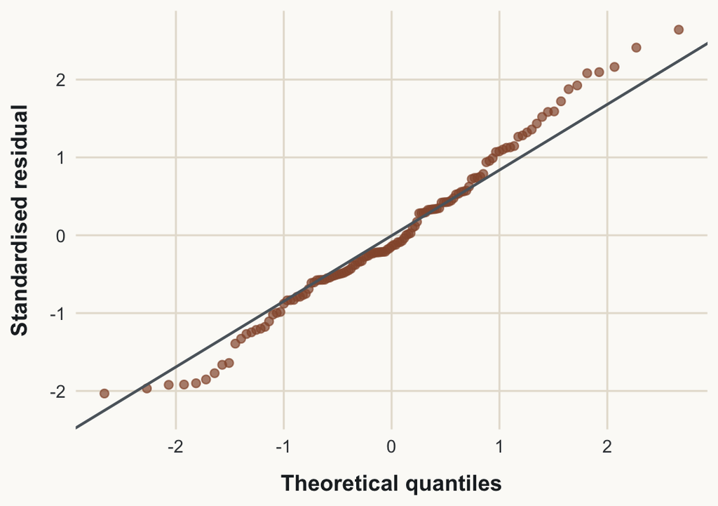

Figure 2: Normal Q-Q of standardised residuals. Points hugging the diagonal support the normality assumption used by the t / F inference.

```r
fit_aug <- broom::augment(fit) |>
  mutate(.std_resid = .resid / sd(.resid, na.rm = TRUE))

# Residuals vs fitted
ggplot(fit_aug, aes(.fitted, .resid)) +
  geom_hline(yintercept = 0,
             colour = "#6c665d", linewidth = 0.5) +
  geom_point(colour = "#945638", alpha = 0.7, size = 1.8) +
  geom_smooth(method = "loess", se = FALSE,
              colour = "#5b646b", linewidth = 0.7, span = 0.9) +
  labs(x = "Fitted log(carbon intensity)",
       y = "Residual") +
  report_theme()

# Normal Q-Q of standardised residuals
ggplot(fit_aug, aes(sample = .std_resid)) +
  stat_qq(colour = "#945638", alpha = 0.7, size = 1.8) +
  stat_qq_line(colour = "#5b646b", linewidth = 0.7) +
  labs(x = "Theoretical quantiles",
       y = "Standardised residual") +
  report_theme()
```

**T**

**T — Test Statistic**

```r
fit_tidy |>
  mutate(across(where(is.numeric), ~ signif(.x, 3))) |>
  kable(caption = "Regression coefficients.")
```

Regression coefficients.

| term | estimate | std.error | statistic | p.value |
| --- | --- | --- | --- | --- |
| (Intercept) | 5.03 | 0.0674 | 74.70 | 0e+00 |
| coal_share | 1.15 | 0.2130 | 5.41 | 3e-07 |

```r
fit_glance |>
  select(r.squared, adj.r.squared, statistic, df, df.residual, p.value, nobs) |>
  mutate(across(where(is.numeric), ~ signif(.x, 3))) |>
  kable(caption = "Model summary.")
```

Model summary.

| r.squared | adj.r.squared | statistic | df | df.residual | p.value | nobs |
| --- | --- | --- | --- | --- | --- | --- |
| 0.187 | 0.181 | 29.3 | 1 | 127 | 3e-07 | 129 |

**P**

**P — P-value**

The p-value for the coal-share slope is **< 0.001**, so the null hypothesis is rejected.

**C**

**C — Conclusion**

There is strong evidence of a positive association between coal dependence and carbon intensity in the 2022 cross-section. This supports the report’s recommendation logic, while still stopping short of causal interpretation.

### Data and Reproducibility Notes

- All aggregate rows with missing `iso_code` or `iso_code` beginning with `OWID` were excluded.
- 2022 was used as the latest year with complete GDP coverage for the focus economies.
- Carbon intensity is defined as `co2 / gdp * 10^12`, giving tonnes of CO2 per million **2011 international (PPP) dollars** of GDP — OWID’s `gdp` column is the Maddison Project series, not market-exchange-rate USD.
- Ten-year CO2 growth is defined as `(CO2_2022 - CO2_2012) / CO2_2012`.
- Latest-year evidence was combined with 2012-2022 trend information to avoid over-relying on a single-year snapshot.
- **Sample composition transparency**: of the 218 country-rows present in OWID for 2022, 129 had complete `carbon_intensity`, `coal_share` and `co2`; the headline regression in the Hypothesis Test subsection then drops a further 0 rows that fail the regression filters (non-positive intensity or out-of-range coal share), leaving **n = 129** countries.

A small set of formatting helpers and a custom ggplot theme keep the inline numbers and every figure stylistically consistent across the report:

**Code — formatting helpers and report_theme()**

```r
# Pull a single metric for a focus country (used in inline numbers)
pluck_metric <- function(cty, var) {
  latest_panel_focus |> filter(country == cty) |> pull({{ var }})
}

# Signed percentage with a fixed number of digits, e.g. "+14%"
fmt_pct <- function(x, digits = 0, signed = TRUE) {
  prefix <- if (signed && x > 0) "+" else ""
  paste0(prefix, round(x, digits), "%")
}

# Shared ggplot theme — warm paper background, muted gridlines
report_theme <- function() {
  theme_minimal(base_size = 12) +
    theme(
      plot.background  = element_rect(fill = "#fbfaf7", colour = NA),
      panel.background = element_rect(fill = "#fbfaf7", colour = NA),
      panel.grid.minor = element_blank(),
      panel.grid.major = element_line(colour = "#e5dfd4", linewidth = 0.5),
      plot.title       = element_text(face = "bold", size = 16, colour = "#20262a"),
      plot.subtitle    = element_text(size = 11.5, colour = "#5b646b"),
      axis.title       = element_text(face = "bold", colour = "#20262a"),
      axis.title.x     = element_text(margin = margin(t = 10)),
      axis.title.y     = element_text(margin = margin(r = 10)),
      axis.text        = element_text(colour = "#3a3f44"),
      axis.text.x      = element_text(margin = margin(t = 2)),
      axis.text.y      = element_text(margin = margin(r = 3)),
      legend.position  = "top"
    )
}
```

## Appendix 2 — Supplementary Analysis

These three sensitivity views ask whether the recommendation changes under alternative cuts of the same OWID data. They are kept in the Appendix because they support transparency, but they are not needed to understand the main recommendation.

**Small multiples: intensity 1990→2022**

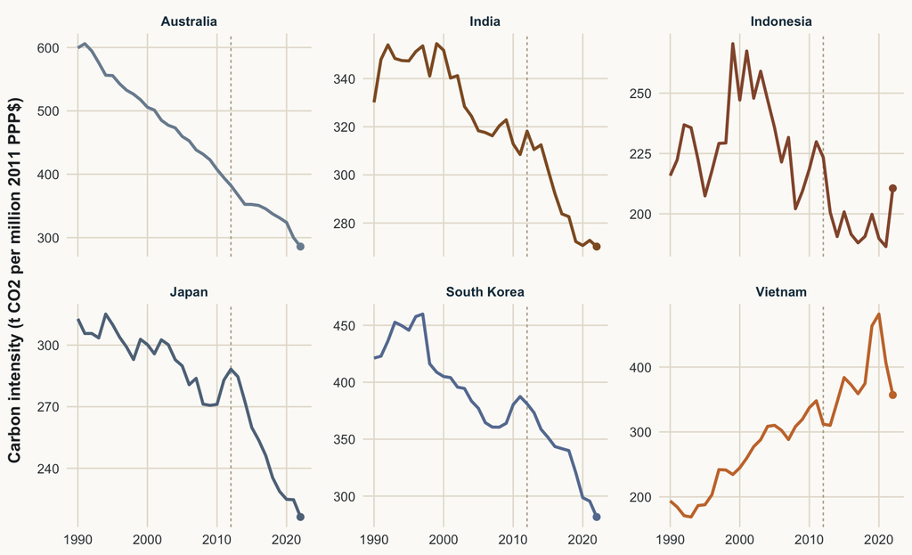

```r
trend_data |>
  mutate(country = factor(country,
                          levels = c("Vietnam", "Indonesia", "India",
                                     "Australia", "Japan", "South Korea"))) |>
  ggplot(aes(x = year, y = carbon_intensity)) +
  geom_vline(xintercept = 2012, colour = "#b8ad9c", linetype = "22", linewidth = 0.5) +
  geom_line(aes(colour = country), linewidth = 1.05, show.legend = FALSE) +
  geom_point(data = trend_labels,
             aes(x = year, y = carbon_intensity, colour = country),
             size = 2, show.legend = FALSE) +
  facet_wrap(~ country, ncol = 3, scales = "free_y") +
  scale_colour_manual(values = c(
    Vietnam = "#c87638",
    Indonesia = "#945638",
    India = "#8f5c2c",
    Australia = "#7b8d9f",
    Japan = "#5f7488",
    `South Korea` = "#667ca0"
  )) +
  scale_x_continuous(breaks = c(1990, 2000, 2010, 2020)) +
  labs(
    x = NULL,
    y = "Carbon intensity (t CO2 per million 2011 PPP$)"
  ) +
  report_theme() +
  theme(
    strip.text = element_text(face = "bold", colour = "#18384a"),
    panel.spacing = unit(1.1, "lines")
  )
```

**Appendix diagnostic.** Carbon intensity trajectories for the six focus economies, 1990-2022. The vertical reference line marks the 2012 baseline used in the report; Vietnam and Indonesia show flatter or rising tails while the benchmark economies bend downward.

Each facet uses its own y-axis so individual shape is legible. The key signal is the **direction** at the 2012 line: Vietnam and Indonesia have flat-to-rising tails, while the three benchmark economies bend downward.

**Focus six on the world fit**

This view places the six focus economies on the same regression line used in the Hypothesis Test subsection (`log(carbon_intensity) ~ coal_share`, n = 129 countries). It bridges the country-specific narrative and the cross-country statistical pattern — if the focus six sit broadly along the world fit, the headline coal-intensity claim is internally consistent.

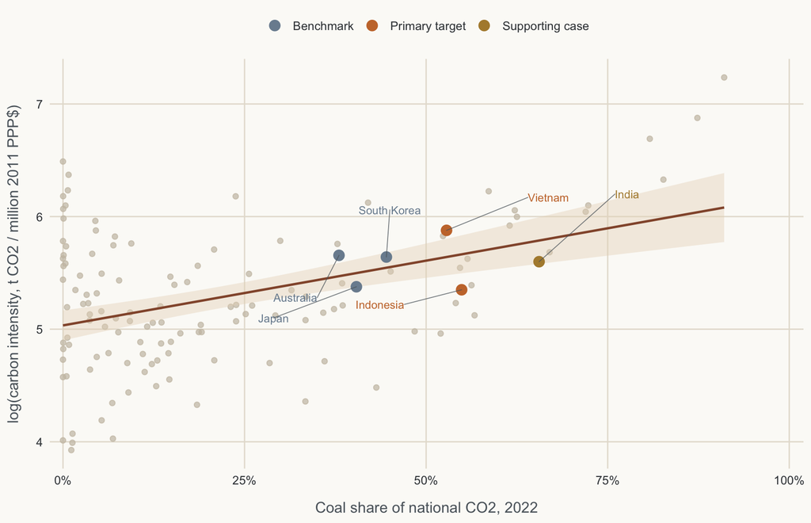

```r
focus_world_data <- reg_data |>
  mutate(
    log_intensity = log(carbon_intensity),
    is_focus = country %in% c("Indonesia", "Vietnam", "India",
                              "Australia", "Japan", "South Korea"),
    role = case_when(
      country %in% c("Indonesia", "Vietnam") ~ "Primary target",
      country == "India"                     ~ "Supporting case",
      country %in% c("Australia", "Japan",
                     "South Korea")          ~ "Benchmark",
      TRUE                                   ~ NA_character_
    )
  )

# Fixed label positions keep the crowded middle of the chart readable.
focus_world_label_positions <- tribble(
  ~country,        ~label_x, ~label_y, ~label_hjust,
  "Vietnam",          0.64,     6.17,          0,
  "Indonesia",        0.47,     5.22,          1,
  "India",            0.76,     6.20,          0,
  "Australia",        0.35,     5.28,          1,
  "Japan",            0.29,     5.10,        0.5,
  "South Korea",      0.45,     6.06,        0.5
)

focus_world_six_lab <- focus_world_data |>
  filter(is_focus) |>
  left_join(focus_world_label_positions, by = "country")

ggplot(focus_world_data, aes(coal_share, log_intensity)) +
  geom_point(data = focus_world_data |> filter(!is_focus),
             colour = "#c9c0b0", size = 1.7, alpha = 0.7) +
  geom_smooth(method = "lm", se = TRUE,
              colour = "#945638", fill = "#e8d6bf",
              alpha = 0.40, linewidth = 0.9) +
  geom_point(data = focus_world_data |> filter(is_focus),
             aes(colour = role), size = 3.6) +
  geom_segment(data = focus_world_six_lab,
               aes(x = coal_share, y = log_intensity,
                   xend = label_x, yend = label_y),
               colour = "#5b646b", linewidth = 0.32,
               alpha = 0.74, lineend = "round") +
  geom_text(data = focus_world_six_lab,
            aes(x = label_x, y = label_y,
                label = country, colour = role, hjust = label_hjust),
            size = 3.15, fontface = "plain",
            show.legend = FALSE) +
  scale_colour_manual(values = c(
    `Primary target`    = "#c87638",
    `Supporting case`   = "#b08a3a",
    Benchmark           = "#7b8d9f"
  )) +
  scale_x_continuous(labels = scales::label_percent(accuracy = 1),
                     expand = expansion(mult = c(0.02, 0.12))) +
  labs(
    x = "Coal share of national CO2, 2022",
    y = "log(carbon intensity, t CO2 / million 2011 PPP$)",
    colour = NULL
  ) +
  report_theme() +
  theme(
    legend.position = "top",
    axis.title = element_text(face = "plain", colour = "#5b646b"),
    axis.title.x = element_text(face = "plain", colour = "#5b646b",
                                margin = margin(t = 12)),
    axis.title.y = element_text(face = "plain", colour = "#5b646b",
                                margin = margin(r = 12)),
    legend.text = element_text(colour = "#3a3f44")
  )
```

**Appendix diagnostic.** Focus six placed on the global coal-share / log(carbon-intensity) fit. Grey points: all OWID countries with complete 2022 data. Orange line: the headline univariate OLS, with 95% confidence ribbon. Coloured points: the six focus economies labelled by priority role.

**Pre-COVID growth (2010 → 2019)**

The headline growth window (2012 → 2022) spans the COVID-19 demand shock. A reasonable objection — especially against Vietnam’s **+106%** decade growth — is that part of the figure could be a 2020–21 rebound effect rather than steady carbon-intensive expansion. This tab repeats the growth comparison on a strictly pre-COVID window (2010 → 2019).

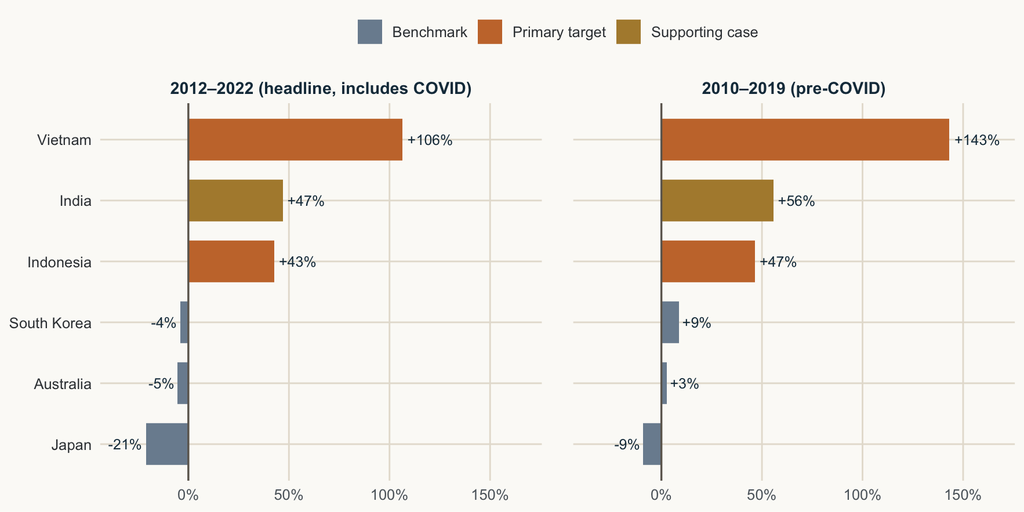

```r
precovid_long <- focus_growth_compare |>
  pivot_longer(
    c(growth_2012_2022, co2_growth_precovid_pct),
    names_to  = "window",
    values_to = "growth_pct"
  ) |>
  mutate(
    window = recode(window,
                    growth_2012_2022          = "2012–2022 (headline, includes COVID)",
                    co2_growth_precovid_pct   = "2010–2019 (pre-COVID)"),
    window = factor(window,
                    levels = c("2012–2022 (headline, includes COVID)",
                               "2010–2019 (pre-COVID)"))
  )

# Order countries by the headline window so both panels share the same y-order
country_order <- focus_growth_compare |>
  arrange(desc(growth_2012_2022)) |>
  pull(country)

precovid_long <- precovid_long |>
  mutate(country = factor(country, levels = rev(country_order)))

ggplot(precovid_long,
       aes(x = growth_pct, y = country, fill = role)) +
  geom_col(width = 0.68) +
  geom_vline(xintercept = 0, colour = "#6c665d", linewidth = 0.6) +
  geom_text(
    aes(label = sprintf("%+.0f%%", growth_pct),
        hjust = ifelse(growth_pct >= 0, -0.12, 1.12)),
    size = 3.3, colour = "#18384a"
  ) +
  facet_wrap(~ window, ncol = 2) +
  scale_fill_manual(values = c(
    `Primary target` = "#c87638",
    `Supporting case` = "#b08a3a",
    Benchmark        = "#7b8d9f"
  )) +
  scale_x_continuous(
    labels = scales::label_percent(scale = 1, accuracy = 1),
    expand = expansion(mult = c(0.14, 0.20))
  ) +
  labs(x = NULL, y = NULL, fill = NULL) +
  report_theme() +
  theme(
    legend.position = "top",
    panel.spacing   = unit(1.4, "lines"),
    strip.text      = element_text(face = "bold", colour = "#18384a", size = 10.8),
    axis.text.x     = element_text(colour = "#5b646b")
  )
```

**Appendix diagnostic.** Ten-year CO2 growth under the headline 2012-2022 window and the pre-COVID 2010-2019 window. Both windows keep Vietnam, Indonesia and India on the growth side, while Australia, Japan and South Korea remain flat or declining.

**The result runs in the opposite direction to the standard objection**: the pre-COVID 2010–2019 window shows **larger** decade growth for every focus economy, not smaller. Vietnam’s number rises from +106% to +143%, India from +47% to +56%, and the benchmarks shift from declines to near-flat. **COVID dampened the apparent growth of carbon-intensive economies; it did not inflate them.** The qualitative ranking — Vietnam > India ≈ Indonesia ≫ {Australia, Japan, South Korea} — holds in both windows, so the priority call is robust to the choice of growth window. If anything, the headline 2012–2022 figures *understate* Vietnam’s underlying carbon-intensive trajectory.